Name: Wonee Pak  
UID: 116612463

[figure not shown]

# Final Project: Which of the 50 states should you climb in?

### Introduction

Climbing gyms are a growing phenomenon and are especially popular amongst computer science students and professionals. Indoor rock climbing and bouldering are more accessible. Climbing gyms provide the majority of the necessary equipment as well as the convenience of a 30-minute commute to the facility and back. It does, however, lack a certain risk-taking thrill that outdoor climbing on the sides of mountains can only provide.  
Rock climbing has been a long tradition of mountaineering and while traditionally done with a rope and protection, free soloing is an especially bold style of climbing. There are so many types of rock climbing. Just to name a few that this data science project will explore there are traditional, sport, toprope, boulder, ice, aid, mixed, and alpine.  
*Trad/Traditional:*  
any climbing that involves removable gear after the pitch is complete  
*Sport:*  
any climbing using fixed protection, as opposed to trad climbing  
*Toprope:*  
rock climbing where climbers are supported by a rope that runs down a rock face  
*Boulder:*  
a style of climbing close to the ground without ropes and with crash mattresses  
*Ice:*  
essentially rock climbing, but on ice  
*Aid:*  
often used on very long, multi-day routes (big walls) and is where climbers use gear to help ascension  
*Mixed:*  
a combination of ice climbing and rock climbing often requires specialized gear  
*Alpine:*  
branch of climbing in which the main objective is often to reach the summit of a mountain

As we can see, there are so many types of rock climbing. Where should one even begin to look? The 50 states have a lot to offer in terms of climbing. Each state has its own set of climbing problems to be solved. But, which state is best for ice climbing? For beginners? For variety? For expert boulderers looking for grade V11 and up?

This data science project will aim to detail the perfect state for every climber based off of climbing type, quantity, and difficulty.

### Gathering Dataset 1: Types of Climbing in the US

The data in this project will be from https://www.mountainproject.com/route-guide.  
Mountain Project is a website that serves as a guidebook to more than 170,000 climbing routes across the world and we will be using it for our exploration of US climbing. This specific link is a web page that houses a climbing directory for each of the 50 states. These directories are hyperlinked on this page. Rather than manually clicking and saving each of the 50 links, I will be scraping them off the web page and storing them in a dictionary structure. A more detailed explanation of the process will be included as we proceed.  
Click on the links below for more information about the tools I will be using to achieve the above:

*BeautifulSoup:*  
Python library for pulling data out of HTML and XML files  
https://www.educative.io/answers/what-is-beautiful-soup

*Pandas:*  
Python package that I will use for data science/data analysis  
https://www.w3schools.com/python/pandas/pandas_intro.asp

*NumPy:*  
Python library used for working with arrays  
https://www.pythontutorial.net/python-numpy/what-is-numpy/

*Seaborn:*  
Python data visualization library based on matplotlib  
https://towardsdatascience.com/seaborn-python-8563c3d0ad41

*Matplotlib:*  
Comprehensive library for creating static, animated, and interactive visualizations in Python  
https://www.activestate.com/resources/quick-reads/what-is-matplotlib-in-python-how-to-use-it-for-plotting/

*Inspect Element in Chrome:*  
Gives insight into the HTML of a webpage  
https://www.browserstack.com/guide/inspect-element-in-chrome

```python
import pandas as pd
from bs4 import BeautifulSoup
import matplotlib.pyplot as pyplot
import seaborn as sns
import numpy as np
import string
import requests
```

```python
url = 'https://www.mountainproject.com/route-guide'
webpage = requests.get(url)

soup = BeautifulSoup(webpage.content, 'html.parser')
```

The following will look for the <a tag with these specific strings since they will house all the hyperlinks on the page. The <href attribute specifies the URL of the page the link goes to and so they will mark all the hyperlinks on the page that I will need to collect into the xs list. After collecting them all I will go through and eliminate duplicates.

```python
xs = []
for x in soup.find_all('a', class_= 'text-truncate float-xs-left'):
    xs.append(x.get('href'))

links = []
for x in xs:
    if x not in links:
        links.append(x)
```

Now, I want to extract only the hyperlinks for the states. If the hyperlink contains the name of a state, I will pull it out and otherwise ignore it. Since the links contain lowercase versions of the state names, the comparator list does as well.

```python
states = ["alabama","alaska","arizona","arkansas","california","colorado", "connecticut","delaware",
          "florida","georgia","hawaii","idaho","illinois","indiana","iowa","kansas","kentucky","louisiana",
          "maine","maryland","massachusetts","michigan","minnesota","mississippi","missouri","montana",
          "nebraska","nevada","new-hampshire","new-jersey","new-mexico","new-york","north-carolina",
          "north-dakota","ohio","oklahoma","oregon","pennsylvania","rhode-island","south-carolina",
          "south-dakota","tennessee","texas","utah","vermont","virginia","washington","west-virginia",
          "wisconsin","wyoming"]

state_links = []
for link in links:
    for state in states:
        if (state in link):
            state_links.append([state, link])
```

After inspection, there are some duplicates due to errors (like arkansas contains the string kansas) that I will manually remove.

```python
state_links.remove(['tennessee','https://www.mountainproject.com/area/105851828/the-tennessee-wall'])
state_links.remove(['alaska',
  'https://www.mountainproject.com/area/105909315/anchorage-south-central-alaska-ice'])
state_links.remove(['virginia', 'https://www.mountainproject.com/area/105855459/west-virginia'])
state_links.remove(['kansas', 'https://www.mountainproject.com/area/105901027/arkansas'])
```

```python
len(state_links) # check that it's 50 links
```

```
50
```

```python
state_links = dict(state_links) # turns [[state, link] [state, link] ...] into a dictionary
```

Now that I have easy access to all the state’s individual pages, I am going to begin extracting the information that I want to store and explore. First, I want the latitude and longitude at the top of each page. Later, I would like to check if there is a correlation between the type of climbing offered in each state and its location geographically.

To do this, I will do a similar process to the one above. I am going to find the data table with the specific markers that I noticed after using the Chrome Inspect tool. After getting the latitude and longitude, I will store them in a DataFrame with the respective state name.

```python
df2 = pd.DataFrame() # Dataframe that will hold ['State', 'Latitude', 'Longitude']

for state, l in state_links.items():
    webpage = requests.get(l) # get data for each state's webpage from the state_links list
    soup = BeautifulSoup(webpage.content, 'html.parser')

    coordinates = []

    for c in soup.find_all('table', class_="description-details"):
        coor = soup.find('td', text = 'GPS:').find_next_sibling('td').text
        coordinates.append(coor)
        # print(coor)

    coordinates = [s.split('\n') for s in coordinates]

    c1 = pd.DataFrame(data = coordinates)
    c1['State'] = state
    df2 = pd.concat([df2, c1])
```

```python
# processing and cleaning the coordinate data
df2 = df2.drop(labels =[2,0,3,4], axis=1)
df2 = df2[['State', 1]]
df2 = df2.rename(columns = {'State':'State', 1:'Coordinates'})
df2 = df2.reset_index()
df2 = df2.drop(labels = 'index', axis=1)

df2[['Latitude', 'Longitude']] = df2['Coordinates'].str.split(',', expand=True)

df2['Longitude'] = [float(s) for s in df2['Longitude']]
df2['Latitude'] = [float(s) for s in df2['Latitude']]
df2 = df2.drop(labels = 'Coordinates', axis=1)
# df2
```

Each of the states has information about the number of each type of climbing (Trad, Sport, Toprope, Boulder, Ice, Aid, Mixed, Alpine) on their web pages. The following will extract the number of each type of climbing for each state and put them into a DataFrame. This information, unlike the coordinates, was harder to find since it is not explicitly visible on the web page itself.  
However, using the Chrome Inspect tool I found that each of the climbing areas linked on the state's web page has a list of the number of each type of climb that they hold and can be located with the tag <span class="lef-nav-[Insert Climb Type]" and so I will be gathering all of those into a DataFrame.  
This portion also utilizes pivot tables. Pivot tables are a quick way to summarize large amounts of data. Since each state will produce a huge DataFrame of each area's count for the type f climbing it is currently a massive mess. The pivot table will allow us to take the sum of each type of climb.  
For more information on pivot tables click here: https://www.machinelearningplus.com/pandas/pandas-pivot-table-in-python/

```python
df = pd.DataFrame() # will hold the number of each climb type
types = ['Trad','Sport','Toprope','Boulder','Ice','Aid','Mixed','Alpine']

for state, l in state_links.items():
    webpage = requests.get(l)
    soup = BeautifulSoup(webpage.content, 'html.parser')

    num = []
    ts = []

    for type in types:
        for n in soup.find_all('span', class_ = "lef-nav-" + type):
            num.append(n.text)
            ts.append(type)

    # Clean up the data strings and convert counts into ints
    num = [s.strip() for s in num]
    num = [s.replace(',','') for s in num]
    num = [s.replace(' /','') for s in num]
    num = map(int, num)

    stuff = pd.DataFrame(data = num)
    stuff['Climb Type'] = ts
    stuff['State'] = state

    table = stuff.pivot_table(columns = 'Climb Type', index = 'State', aggfunc = np.sum)
    # display(table)
    df = pd.concat([df, table])
```

```python
df = df[0]
```

```python
# Total number of climbs in the State (sum all types)
totals = df.sum(axis = 1)
state_totals = pd.DataFrame(columns = ["State", "total"])
i = 0
for t in totals:
    temp = pd.DataFrame({'State' : states[i], 'total' : t}, index=[i])
    state_totals = pd.concat([state_totals, temp])
    i = i + 1
```

```python
sorted_table = state_totals.copy()
```

```python
df = df.reset_index()
```

```python
df2 = df2.join(df, rsuffix='2')
df2 = df2.drop(labels='State2', axis=1)
df2 = df2.join(state_totals, rsuffix='2')
df2 = df2.drop(labels='State2', axis=1)
```

```python
df2 # final DataFrame of information for climb types in each state
```

|  | State | Latitude | Longitude | Aid | Alpine | Boulder | Ice | Mixed | Sport | Toprope | Trad | total |
| --- | --- | --- | --- | --- | --- | --- | --- | --- | --- | --- | --- | --- |
| 0 | alabama | 33.761 | -86.880 | 0 | 0 | 1184 | 0 | 0 | 400 | 111 | 259 | 1954 |
| 1 | alaska | 64.737 | -150.732 | 24 | 628 | 414 | 287 | 83 | 731 | 245 | 941 | 3353 |
| 2 | arizona | 34.380 | -112.061 | 99 | 18 | 3431 | 0 | 0 | 4742 | 539 | 4217 | 13046 |
| 3 | arkansas | 36.007 | -93.188 | 1 | 0 | 841 | 1 | 0 | 1305 | 89 | 505 | 2742 |
| 4 | california | 37.744 | -119.581 | 351 | 1778 | 14128 | 117 | 63 | 10326 | 3913 | 13243 | 43919 |
| 5 | colorado | 38.967 | -106.062 | 271 | 1752 | 10338 | 849 | 592 | 11503 | 2260 | 11000 | 38565 |
| 6 | connecticut | 41.509 | -72.861 | 1 | 0 | 1509 | 7 | 3 | 102 | 567 | 641 | 2830 |
| 7 | delaware | 38.823 | -75.443 | 0 | 0 | 55 | 0 | 1 | 0 | 19 | 2 | 77 |
| 8 | florida | 28.565 | -81.387 | 0 | 0 | 64 | 0 | 0 | 1 | 4 | 1 | 70 |
| 9 | georgia | 33.715 | -84.386 | 8 | 0 | 967 | 5 | 1 | 79 | 133 | 280 | 1473 |
| 10 | hawaii | 21.167 | -157.940 | 0 | 0 | 279 | 0 | 0 | 66 | 54 | 19 | 418 |
| 11 | idaho | 43.644 | -114.697 | 19 | 272 | 1077 | 23 | 10 | 2129 | 425 | 1101 | 5056 |
| 12 | illinois | 37.726 | -89.217 | 3 | 0 | 702 | 21 | 0 | 591 | 192 | 292 | 1801 |
| 13 | indiana | 40.086 | -86.086 | 0 | 0 | 154 | 0 | 0 | 6 | 8 | 4 | 172 |
| 14 | iowa | 41.935 | -93.538 | 2 | 8 | 316 | 1 | 0 | 127 | 68 | 36 | 558 |
| 15 | kansas | 38.333 | -98.767 | 0 | 0 | 186 | 0 | 0 | 14 | 18 | 11 | 229 |
| 16 | kentucky | 37.579 | -85.078 | 5 | 0 | 342 | 1 | 0 | 2093 | 55 | 816 | 3312 |
| 17 | louisiana | 31.409 | -92.681 | 0 | 0 | 6 | 0 | 0 | 0 | 0 | 0 | 6 |
| 18 | maine | 45.151 | -69.170 | 5 | 28 | 633 | 46 | 5 | 275 | 188 | 507 | 1687 |
| 19 | maryland | 39.300 | -76.630 | 8 | 6 | 951 | 0 | 0 | 31 | 793 | 555 | 2344 |
| 20 | massachusetts | 42.399 | -71.826 | 3 | 3 | 4759 | 18 | 3 | 116 | 665 | 360 | 5927 |
| 21 | michigan | 45.846 | -84.736 | 1 | 9 | 829 | 112 | 9 | 140 | 347 | 181 | 1628 |
| 22 | minnesota | 45.890 | -94.570 | 3 | 134 | 978 | 72 | 59 | 376 | 623 | 405 | 2650 |
| 23 | mississippi | 33.071 | -89.695 | 2 | 0 | 70 | 0 | 0 | 0 | 25 | 5 | 102 |
| 24 | missouri | 38.962 | -92.321 | 1 | 0 | 793 | 2 | 1 | 645 | 156 | 150 | 1748 |
| 25 | montana | 46.432 | -112.840 | 15 | 395 | 868 | 148 | 86 | 1240 | 304 | 851 | 3907 |
| 26 | nebraska | 41.817 | -99.953 | 0 | 0 | 8 | 0 | 0 | 0 | 1 | 0 | 9 |
| 27 | nevada | 39.028 | -116.631 | 29 | 88 | 1213 | 14 | 3 | 2166 | 245 | 1891 | 5649 |
| 28 | new-hampshire | 43.580 | -71.719 | 63 | 314 | 2892 | 389 | 92 | 1217 | 324 | 2367 | 7658 |
| 29 | new-jersey | 40.313 | -74.553 | 18 | 0 | 418 | 5 | 1 | 1 | 234 | 203 | 880 |
| 30 | new-mexico | 34.561 | -105.952 | 29 | 145 | 1232 | 26 | 13 | 2495 | 584 | 1945 | 6469 |
| 31 | new-york | 41.968 | -74.443 | 20 | 34 | 1687 | 391 | 119 | 401 | 1230 | 2530 | 6412 |
| 32 | north-carolina | 35.604 | -79.277 | 31 | 10 | 1099 | 43 | 8 | 621 | 312 | 1703 | 3827 |
| 33 | north-dakota | 47.140 | -100.433 | 1 | 0 | 31 | 0 | 0 | 14 | 13 | 14 | 73 |
| 34 | ohio | 39.960 | -83.013 | 1 | 0 | 1634 | 3 | 0 | 242 | 268 | 117 | 2265 |
| 35 | oklahoma | 35.604 | -97.559 | 19 | 0 | 913 | 0 | 1 | 182 | 268 | 489 | 1872 |
| 36 | oregon | 44.042 | -120.292 | 26 | 99 | 1054 | 37 | 17 | 2346 | 568 | 1259 | 5406 |
| 37 | pennsylvania | 40.928 | -77.347 | 8 | 0 | 2030 | 40 | 15 | 714 | 492 | 500 | 3799 |
| 38 | rhode-island | 41.807 | -71.406 | 0 | 0 | 1628 | 1 | 0 | 9 | 34 | 5 | 1677 |
| 39 | south-carolina | 33.651 | -80.947 | 1 | 0 | 39 | 0 | 0 | 69 | 20 | 128 | 257 |
| 40 | south-dakota | 44.120 | -104.036 | 5 | 0 | 1038 | 22 | 17 | 1452 | 274 | 986 | 3794 |
| 41 | tennessee | 35.604 | -85.869 | 30 | 0 | 973 | 1 | 1 | 1330 | 85 | 706 | 3126 |
| 42 | texas | 30.288 | -97.726 | 2 | 10 | 2014 | 1 | 0 | 1269 | 358 | 308 | 3962 |
| 43 | utah | 40.657 | -111.770 | 606 | 803 | 4522 | 249 | 116 | 5857 | 784 | 6245 | 19182 |
| 44 | vermont | 44.247 | -72.578 | 5 | 86 | 1244 | 111 | 29 | 287 | 122 | 422 | 2306 |
| 45 | virginia | 36.905 | -80.144 | 2 | 1 | 4273 | 9 | 0 | 671 | 485 | 752 | 6193 |
| 46 | washington | 47.398 | -120.762 | 64 | 534 | 2999 | 138 | 100 | 3782 | 753 | 3105 | 11475 |
| 47 | west-virginia | 38.069 | -81.081 | 4 | 47 | 1981 | 0 | 0 | 1270 | 242 | 1215 | 4759 |
| 48 | wisconsin | 44.465 | -89.473 | 1 | 0 | 3021 | 46 | 3 | 196 | 1321 | 1219 | 5807 |
| 49 | wyoming | 43.005 | -107.842 | 66 | 846 | 916 | 141 | 45 | 3297 | 218 | 1947 | 7476 |

### Dataset 1 Exploration and Visualization

It's a lot! We have a lot of data in the DataFrame at the moment. I now want to see what's going on and hopefully gain some insight into what states are best for each climber. To start, I am going to produce a bar plot to easily see what states offer the most in quantity.

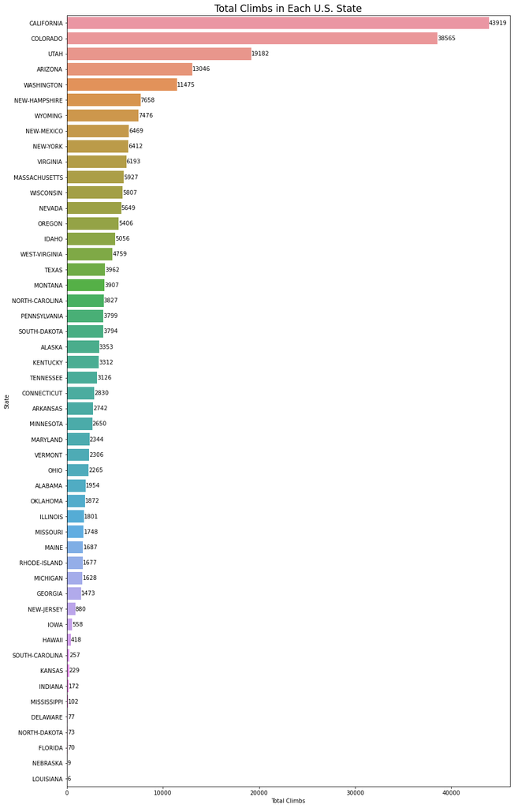

```python
sorted_table = df2.sort_values('total', ascending = False)
sorted_table['State'] = [s.upper() for s in sorted_table['State']]
sorted_table['total'] = [int(s) for s in sorted_table['total']]

pyplot.figure(figsize=(14,25))

ax = sns.barplot(y=sorted_table['State'], x=sorted_table['total'])
ax.bar_label(ax.containers[0])


pyplot.ylabel("State")
pyplot.xlabel("Total Climbs")
pyplot.title("Total Climbs in Each U.S. State",fontdict={'fontsize':17})
```

From this bar plot, it is clear that California and Colorado are where it's at. They are the clear outliers and the distribution of this sorted data is resembling the power law distribution where states like California and Colorado have very large counts and the rest are much smaller.  
So, right off the bat, I can see that California and Colorado as well as Utah and perhaps Arizona followed by Washington would be promising for most climbers due to the sheer quantity in climbs.  
I want a clearer picture about the distribution of the types of climbs in each state so a stacked bar plot that presents the percentages of each type of climb out of the total climbs may help.

[figure not shown]

```python
df3 = df2.copy()
df3['State'] = [s.upper() for s in df3['State']]
df3 = df3.drop(labels=['Latitude', 'Longitude'], axis=1)

# Percentage stacked barplot rather than raw values
for index, row in df3.iterrows():
    df3.at[index, 'Aid'] = row['Aid']/row['total']
    df3.at[index, 'Alpine'] = row['Alpine']/row['total']
    df3.at[index, 'Boulder'] = row['Boulder']/row['total']
    df3.at[index, 'Ice'] = row['Ice']/row['total']
    df3.at[index, 'Mixed'] = row['Mixed']/row['total']
    df3.at[index, 'Sport'] = row['Sport']/row['total']
    df3.at[index, 'Toprope'] = row['Toprope']/row['total']
    df3.at[index, 'Trad'] = row['Trad']/row['total']

df3 = df3.drop(labels=['total'], axis=1)
df3 = df3.sort_values('State', ascending=False)

ax = df3.set_index('State').plot(kind='barh', figsize =(20,27),stacked=True, colormap='gist_rainbow_r', fontsize=15)

pyplot.ylabel("State", fontdict={'fontsize':20})
pyplot.xlabel("Total Climbs", fontdict={'fontsize':20})
pyplot.title("Total Climbs in Each U.S. State By Type", fontdict={'fontsize':24})
ax.legend(types, loc='center left', bbox_to_anchor=(1, 0.25), fontsize=15)
```

```python
types_max = pd.DataFrame(df2[['State', 'total']])
types_max = types_max.sort_values('total', ascending=False, ignore_index=True)
types_max['State'] = [x.capitalize() for x in types_max['State']]

for type in types:
    tdf = pd.DataFrame(df2[['State', type]])
    tdf = tdf.sort_values(type, ascending=False, ignore_index=True)
    tdf['State'] = [x.capitalize() for x in tdf['State']]
    types_max = types_max.join(tdf, rsuffix=" ")

types_max.head(10)
```

|  | State | total | State | Trad | State | Sport | State | Toprope | State | Boulder | State | Ice | State | Aid | State | Mixed | State | Alpine |
| --- | --- | --- | --- | --- | --- | --- | --- | --- | --- | --- | --- | --- | --- | --- | --- | --- | --- | --- |
| 0 | California | 43919 | California | 13243 | Colorado | 11503 | California | 3913 | California | 14128 | Colorado | 849 | Utah | 606 | Colorado | 592 | California | 1778 |
| 1 | Colorado | 38565 | Colorado | 11000 | California | 10326 | Colorado | 2260 | Colorado | 10338 | New-york | 391 | California | 351 | New-york | 119 | Colorado | 1752 |
| 2 | Utah | 19182 | Utah | 6245 | Utah | 5857 | Wisconsin | 1321 | Massachusetts | 4759 | New-hampshire | 389 | Colorado | 271 | Utah | 116 | Wyoming | 846 |
| 3 | Arizona | 13046 | Arizona | 4217 | Arizona | 4742 | New-york | 1230 | Utah | 4522 | Alaska | 287 | Arizona | 99 | Washington | 100 | Utah | 803 |
| 4 | Washington | 11475 | Washington | 3105 | Washington | 3782 | Maryland | 793 | Virginia | 4273 | Utah | 249 | Wyoming | 66 | New-hampshire | 92 | Alaska | 628 |
| 5 | New-hampshire | 7658 | New-york | 2530 | Wyoming | 3297 | Utah | 784 | Arizona | 3431 | Montana | 148 | Washington | 64 | Montana | 86 | Washington | 534 |
| 6 | Wyoming | 7476 | New-hampshire | 2367 | New-mexico | 2495 | Washington | 753 | Wisconsin | 3021 | Wyoming | 141 | New-hampshire | 63 | Alaska | 83 | Montana | 395 |
| 7 | New-mexico | 6469 | Wyoming | 1947 | Oregon | 2346 | Massachusetts | 665 | Washington | 2999 | Washington | 138 | North-carolina | 31 | California | 63 | New-hampshire | 314 |
| 8 | New-york | 6412 | New-mexico | 1945 | Nevada | 2166 | Minnesota | 623 | New-hampshire | 2892 | California | 117 | Tennessee | 30 | Minnesota | 59 | Idaho | 272 |
| 9 | Virginia | 6193 | Nevada | 1891 | Idaho | 2129 | New-mexico | 584 | Pennsylvania | 2030 | Michigan | 112 | New-mexico | 29 | Wyoming | 45 | New-mexico | 145 |

As expected, either California or Colorado are consistently in the top 10 of each type of climbing. Utah was solified as a top and opportunous climbing state in this DataFrame. Arizona and Washington were often present in the top 5 as well. Utah and Arizona have a lot of mountainous regions. For bouldering, California, Colorado, and Massachusetts seem to have the most options, for example. Going forward, I will be using California, Colorado, Utah, Arizona, and Washington as the top five states for climbing.  
I am curious to see if there is a relationship in the type of climbing that is available and the type of problems that are mapped. I also wonder if there is a connection in geography. When seeking out which state to climb in, perhaps a certain type of climbing will reasonably also be around another type of climbing in that state.

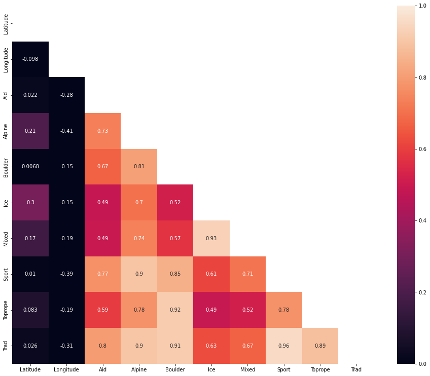

```python
pyplot.figure(figsize=(16, 13))
df4 = df2.copy()

mask = np.triu(np.ones_like(df4.corr(), dtype=bool))

sns.heatmap(df4.corr(), annot=True, mask=mask, vmin =0, vmax=1);
```

There appears to be an almost negligible connection between latitude and the climbing types except for with ice climbing, which seems reasonable since states that are higher up on the map would be colder. We see the strongest correlation between sport climbing trad climbing. This is interesting because trad climbing and sport climbing seem to be opposites of each other and yet they are most correlated. Bouldering and toproping also have a strong correlation and so states with bouldering will also be more likely to have toproping available. So when seeking out a state with a great alpine climbing scene, one could expect to see trad climbing problems there as well.

### Gathering Dataset 2: Climbing Grades in the US

Now that I have created some tools for climbers to figure out which states to go to for a specific type of climbing, I want to delve into the best state for the different climbing grades. Climbs are rated on either a rock climbing scale. Typically, climbing grades do fall into a rudimentary scale of difficulty. A 5.0 to 5.7 is considered easy, 5.8 to 5.10 is considered intermediate, 5.11 to 5.12 is hard, and 5.13 to 5.15 is reserved for a very elite few. Bouldering problems are rated on a different scale. This system ranges from V0 to V16, with V0 considered to be easy and V16 saved for the elite.  
In order to do this, I am going to scrape climbing grades and quantity for each of the states using the same hyperlinks that I collected in the previous sections. This was again, slightly challenging since this information wasn't in an easily identifiable table and instead I found it inside a variable of an embedded script on the webpage. I first grabbed the entire string and then processed it to be the strings ["rating", "count"] for each state. Also, since rock climbing and bouldering follow different ratings, I will be makings two different DataFrames.

```python
ratings = pd.DataFrame() # will hold the scraped and split strings of rock and boulder [grade, count]

for state, l in state_links.items():
    x = []
    webpage = requests.get(l)
    soup = BeautifulSoup(webpage.content, 'html.parser')

    c = soup.find_all('script', {'type':'text/javascript'})
    c = c[6].string.split('var data = {')
    c = c[1].split(';')
    c = c[0]
    c = c.split('"boulder"')

    x.append({'state':state, 'rock':c[0], 'boulder':c[1]})
    d = pd.DataFrame(x)

    ratings = pd.concat([ratings, d])

ratings = ratings.sort_values('state')
ratings = ratings.reset_index()
ratings = ratings.drop(labels='index', axis=1)
# ratings
```

```python
rcs = pd.DataFrame(columns = ['Rating', 'Count'])  # will hold the final processed list of Rock Climbing ratings and counts for each state
i = 0
for r in ratings['rock']:
    curr = []
    state = (ratings.at[i, 'state'])
    i = i+1
    x = r.split('"rock":[')
    x = x[1].split('],')
    for s in x:
        rc = s.split(',"')
        u = rc[0].split("', '")
        y = u[0].split(',')
        # display(y[1])

        yw = y[0].split('["')

        if len(yw)==2:
            yw = yw[1].replace('"', '')
            curr.append({'state':state, 'Rating':yw, 'Count':y[1]})
        else:
            curr.append({'state':state, 'Rating':yw[0], 'Count':y[1]})

        temp = pd.DataFrame(curr)
        rcs = pd.concat([rcs, temp])


rcs = rcs[['state', 'Rating', 'Count']]
rcs = rcs.drop_duplicates(keep='first')
rcs = rcs.reset_index()
```

```python
i = 0
for r in rcs['Rating']:
    if "total" in r:
        rcs = rcs.drop(index=[i])
    i = i+1
rcs = rcs.reset_index()
```

```python
# array(['<5.6', '5.7', '5.8', '5.9', '5.10', '5.11', '5.12', '>=5.13'],
#       dtype=object)

numeric_1 = [] # assign numberic value to each rating for plotting later on
for r in rcs['Rating']:
    if r == '<5.6':
        numeric_1.append(6)
    elif r == '5.7':
        numeric_1.append(7)
    elif r == '5.8':
        numeric_1.append(8)
    elif r == '5.9':
        numeric_1.append(9)
    elif r == '5.10':
        numeric_1.append(10)
    elif r == '5.11':
        numeric_1.append(11)
    elif r == '5.12':
        numeric_1.append(12)
    elif r == '>=5.13':
        numeric_1.append(13)
n1 = pd.DataFrame(numeric_1)

rcs = rcs.join(n1, rsuffix="")
rcs = rcs.rename(columns = {0:'Numeric Grade'})
rcs = rcs.drop(labels = ['level_0', 'index'], axis=1)

rcs
```

|  | state | Rating | Count | Numeric Grade |
| --- | --- | --- | --- | --- |
| 0 | alabama | <5.6 | 34 | 6 |
| 1 | alabama | 5.7 | 29 | 7 |
| 2 | alabama | 5.8 | 68 | 8 |
| 3 | alabama | 5.9 | 86 | 9 |
| 4 | alabama | 5.10 | 132 | 10 |
| ... | ... | ... | ... | ... |
| 395 | wyoming | 5.9 | 531 | 9 |
| 396 | wyoming | 5.10 | 1267 | 10 |
| 397 | wyoming | 5.11 | 1224 | 11 |
| 398 | wyoming | 5.12 | 853 | 12 |
| 399 | wyoming | >=5.13 | 274 | 13 |

400 rows × 4 columns

We see this DataFrame rcs that holds how many climbs of each rating that each state has. Also, since the ratings are not necessarily numberic values, I will assign them a number based on their decimal rating for plotting later on.  
I am going to repeat a similar scraping and data cleanign process for the bouldering data.

```python
rcs2 = pd.DataFrame(columns = ['Rating', 'Count'])  # Bouldering rating and counts
i = 0
for r in ratings['boulder']:
    curr = []
    state = (ratings.at[i, 'state'])
    i = i+1
    x = r.split(':[')
    x = x[1].split('],')
    for s in x:
        rc = s.split(',"')
        u = rc[0].split("', '")
        y = u[0].split(',')
        # display(y)

        yw = y[0].split('["')

        if len(yw)==2:
            yw = yw[1].replace('"', '')
            curr.append({'state':state, 'Rating':yw, 'Count':y[1]})
        else:
            curr.append({'state':state, 'Rating':yw[0], 'Count':y[0]})

        temp2 = pd.DataFrame(curr)
        rcs2 = pd.concat([rcs2, temp2])


rcs2 = rcs2[['state', 'Rating', 'Count']]
rcs2 = rcs2.drop_duplicates(keep='first')
rcs2 =rcs2.reset_index()
# rcs2
```

```python
i=0
for r in rcs2['Rating']:
    if "total" in r:
        rcs2 = rcs2.drop(index=[i])
        # rcs2 =rcs2.reset_index()
    i = i+1
rcs2 =rcs2.reset_index()
```

```python
# array(['<V1', 'V2-3', 'V4-5', 'V6-7', 'V8-9', 'V10-11', 'V12-13', '>=V14'],
#       dtype=object)

numeric_2 = [] # numeric value for the climbing ratings
for r in rcs2['Rating']:
    if r == '<V1':
        numeric_2.append(1)
    elif r == 'V2-3':
        numeric_2.append(2.5)
    elif r == 'V4-5':
        numeric_2.append(4.5)
    elif r == 'V6-7':
        numeric_2.append(6.5)
    elif r == 'V8-9':
        numeric_2.append(8.5)
    elif r == 'V10-11':
        numeric_2.append(10.5)
    elif r == 'V12-13':
        numeric_2.append(12.5)
    elif r == '>=V14':
        numeric_2.append(14)
n2 = pd.DataFrame(numeric_2)

rcs2 = rcs2.join(n2, rsuffix="")
rcs2 = rcs2.rename(columns = {0:'Numeric Grade'})
rcs2 = rcs2.drop(labels = ['level_0', 'index'], axis=1)
rcs2
```

|  | state | Rating | Count | Numeric Grade |
| --- | --- | --- | --- | --- |
| 0 | alabama | <V1 | 0 | 1.0 |
| 1 | alabama | V2-3 | 398 | 2.5 |
| 2 | alabama | V4-5 | 243 | 4.5 |
| 3 | alabama | V6-7 | 131 | 6.5 |
| 4 | alabama | V8-9 | 71 | 8.5 |
| ... | ... | ... | ... | ... |
| 395 | wyoming | V6-7 | 125 | 6.5 |
| 396 | wyoming | V8-9 | 53 | 8.5 |
| 397 | wyoming | V10-11 | 20 | 10.5 |
| 398 | wyoming | V12-13 | 3 | 12.5 |
| 399 | wyoming | >=V14 | 0 | 14.0 |

400 rows × 4 columns

Now that we have these two DataFrames (rcs = Rock Climbing ratings and counts, rcs2 = Bouldering ratings and counts) I am going to explore the top 5 states that I pulled out in the previous section as the most popular states. This way the data is more digestible and as we saw earlier with the power law distribution, not all states have very many climbs to contribute and assess. I will need to pull these five states for both bouldering and rock climbing.

```python
# cal col ariz utah wash
pop_states = ['california', 'colorado', 'arizona', 'utah', 'washington']
popular_rock = pd.DataFrame()
popular_boulder = pd.DataFrame(columns = ['state', 'Rating', 'Count'])

for state in pop_states:
    r = rcs.loc[rcs['state'] == state]
    popular_rock = pd.concat([popular_rock, r])
    r2 = rcs2.loc[rcs['state'] == state]
    popular_boulder = pd.concat([popular_boulder, r2])
```

```python
popular_rock = popular_rock.reset_index()
popular_rock['state'] = [x.capitalize() for x in popular_rock['state']]

popular_boulder = popular_boulder.reset_index()
popular_boulder['state'] = [x.capitalize() for x in popular_boulder['state']]
```

```python
popular_rock.head(5)
```

|  | index | state | Rating | Count | Numeric Grade |
| --- | --- | --- | --- | --- | --- |
| 0 | 32 | California | <5.6 | 2327 | 6 |
| 1 | 33 | California | 5.7 | 2088 | 7 |
| 2 | 34 | California | 5.8 | 2829 | 8 |
| 3 | 35 | California | 5.9 | 3274 | 9 |
| 4 | 36 | California | 5.10 | 7890 | 10 |

```python
popular_boulder.head(5)
```

|  | index | state | Rating | Count | Numeric Grade |
| --- | --- | --- | --- | --- | --- |
| 0 | 32 | California | <V1 | 0 | 1.0 |
| 1 | 33 | California | V2-3 | 3616 | 2.5 |
| 2 | 34 | California | V4-5 | 2279 | 4.5 |
| 3 | 35 | California | V6-7 | 1266 | 6.5 |
| 4 | 36 | California | V8-9 | 624 | 8.5 |

One thing that I think is important to consider is that California and Colorado have substantially more climbs than other states. I think it will be important to grab the percentage of each climbing grade available out of the total number of climbs available for rock climbing and bouldering respectively.

```python
rt = {'state': ['California', 'Colorado', 'Arizona', 'Utah', 'Washington'],
             'total': [25428,21508,8849,12022,6835]}
rock_total = pd.DataFrame(data=rt)

rb = {'state': ['California', 'Colorado', 'Arizona', 'Utah', 'Washington'],
             'total': [8064,7552,2331,3414,2083]}
boulder_total = pd.DataFrame(data=rb)
```

```python
percents = []
for index, row in popular_boulder.iterrows():
    if row['state'] == 'California':
        p = int(row['Count'])/int(boulder_total['total'].loc[boulder_total['state'] == 'California'])
        percents.append(p)
    elif row['state'] == 'Colorado':
        p = int(row['Count'])/int(boulder_total['total'].loc[boulder_total['state'] == 'Colorado'])
        percents.append(p)
    elif row['state'] == 'Arizona':
        p = int(row['Count'])/int(boulder_total['total'].loc[boulder_total['state'] == 'Arizona'])
        percents.append(p)
    elif row['state'] == 'Utah':
        p = int(row['Count'])/int(boulder_total['total'].loc[boulder_total['state'] == 'Utah'])
        percents.append(p)
    elif row['state'] == 'Washington':
        p = int(row['Count'])/int(boulder_total['total'].loc[boulder_total['state'] == 'Washington'])
        percents.append(p)

popular_boulder['Percentage'] = pd.DataFrame(percents)
```

```python
percents = []
for index, row in popular_rock.iterrows():
    if row['state'] == 'California':
        p = int(row['Count'])/int(rock_total['total'].loc[rock_total['state'] == 'California'])
        percents.append(p)
    elif row['state'] == 'Colorado':
        p = int(row['Count'])/int(rock_total['total'].loc[rock_total['state'] == 'Colorado'])
        percents.append(p)
    elif row['state'] == 'Arizona':
        p = int(row['Count'])/int(rock_total['total'].loc[rock_total['state'] == 'Arizona'])
        percents.append(p)
    elif row['state'] == 'Utah':
        p = int(row['Count'])/int(rock_total['total'].loc[rock_total['state'] == 'Utah'])
        percents.append(p)
    elif row['state'] == 'Washington':
        p = int(row['Count'])/int(rock_total['total'].loc[rock_total['state'] == 'Washington'])
        percents.append(p)

popular_rock['Percentage'] = pd.DataFrame(percents)
```

```python
popular_boulder.head(5)
```

|  | index | state | Rating | Count | Numeric Grade | Percentage |
| --- | --- | --- | --- | --- | --- | --- |
| 0 | 32 | California | <V1 | 0 | 1.0 | 0.000000 |
| 1 | 33 | California | V2-3 | 3616 | 2.5 | 0.448413 |
| 2 | 34 | California | V4-5 | 2279 | 4.5 | 0.282614 |
| 3 | 35 | California | V6-7 | 1266 | 6.5 | 0.156994 |
| 4 | 36 | California | V8-9 | 624 | 8.5 | 0.077381 |

```python
popular_rock.head(5)
```

|  | index | state | Rating | Count | Numeric Grade | Percentage |
| --- | --- | --- | --- | --- | --- | --- |
| 0 | 32 | California | <5.6 | 2327 | 6 | 0.091513 |
| 1 | 33 | California | 5.7 | 2088 | 7 | 0.082114 |
| 2 | 34 | California | 5.8 | 2829 | 8 | 0.111255 |
| 3 | 35 | California | 5.9 | 3274 | 9 | 0.128756 |
| 4 | 36 | California | 5.10 | 7890 | 10 | 0.310288 |

In order to better assess this data, I am going to make plots that show the number of each climbing grade in these 5 states. To account for the immense difference in number of climbs available, I will be plotting percentages as well as the total counts.

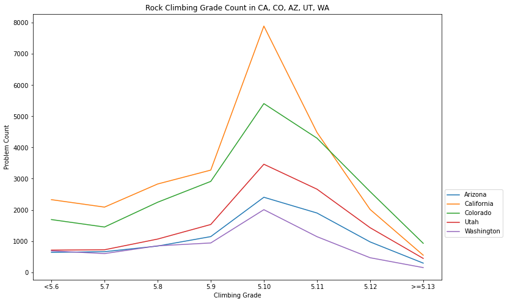

```python
import math
# pop_states = ['california', 'colorado', 'arizona', 'utah', 'washington']
popular_rock['Count'] = [int(s) for s in popular_rock['Count']]

california = popular_rock.loc[popular_rock['state']=='california']
colorado = popular_rock.loc[popular_rock['state']=='colorado']
arizona = popular_rock.loc[popular_rock['state']=='arizona']
utah = popular_rock.loc[popular_rock['state']=='utah']
washington = popular_rock.loc[popular_rock['state']=='washington']

fig, ax1 = pyplot.subplots(figsize=(12,8))
r_states = []

for key, t in popular_rock.groupby(['state']):
    r_states.append(key)
    ax1.plot(t['Numeric Grade'], t['Count'])

ax1.legend(r_states, loc='center left', bbox_to_anchor=(1, 0.25))
ticks = ['<5.6', '5.7', '5.8', '5.9', '5.10', '5.11', '5.12', '>=5.13']
pyplot.xticks(t['Numeric Grade'], ticks)
pyplot.xlabel("Climbing Grade")
pyplot.ylabel("Problem Count")
pyplot.title("Rock Climbing Grade Count in CA, CO, AZ, UT, WA")
pyplot.show()
```

This plot is showing the total counts for each climbing grade. It is interesting to see that even regardless of California having the most number of climbs total, Colorado still has more of 5.12 and up rock climbing problems.  
To see the data at a more level field, I will plot the percentages for the rock climbing problems next.

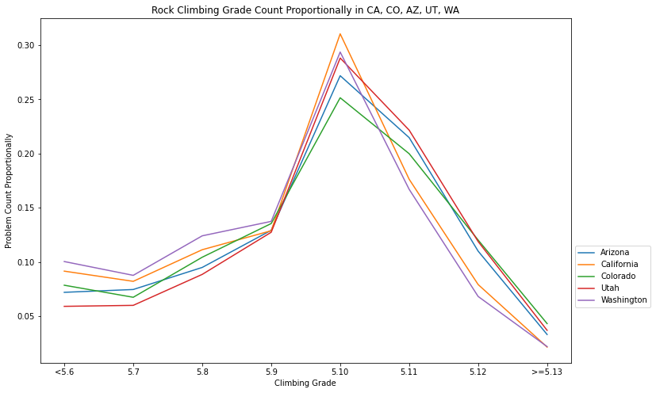

```python
# pop_states = ['california', 'colorado', 'arizona', 'utah', 'washington']
fig, ax1 = pyplot.subplots(figsize=(12,8))
r_states = []

for key, t in popular_rock.groupby(['state']):
    r_states.append(key)
    ax1.plot(t['Numeric Grade'], t['Percentage'])

ax1.legend(r_states, loc='center left', bbox_to_anchor=(1, 0.25))
pyplot.xticks(t['Numeric Grade'], ticks)
pyplot.xlabel("Climbing Grade")
pyplot.ylabel("Problem Count Proportionally")
pyplot.title("Rock Climbing Grade Count Proportionally in CA, CO, AZ, UT, WA")
pyplot.show()
```

There appears to be a similar trend for rock climbing problems. All 5 states seems to have a majority number of 5.10 problems. We can see that proprotionally both California and Washnigton seem to have less 5.11 and up problems than the other three states. Washington has the most variety for the lower climbing grades while Utah's climbs are the least <5.6 - 5.9 problems. So, amateur rock climbers will have the most to do in Washington and for those that are higher grade climbers Arizona, Utah, and Colorado will be most interesting.  
I am going to repeat this process for the bouldering data. However, the percentage data seems to be more valuable and appropriate so I will only be plotting the percentage data.

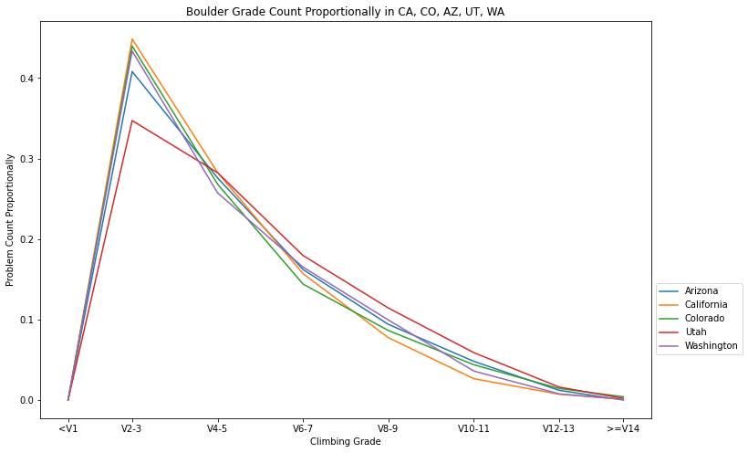

```python
# pop_states = ['california', 'colorado', 'arizona', 'utah', 'washington']
popular_boulder['Count'] = [int(s) for s in popular_boulder['Count']]

california = popular_boulder.loc[popular_boulder['state']=='california']
colorado = popular_boulder.loc[popular_boulder['state']=='colorado']
arizona = popular_boulder.loc[popular_boulder['state']=='arizona']
utah = popular_boulder.loc[popular_boulder['state']=='utah']
washington = popular_boulder.loc[popular_boulder['state']=='washington']

fig, ax = pyplot.subplots(figsize=(12,8))
b_states = []

for key, t in popular_boulder.groupby(['state']):
    b_states.append(key)
    ax.plot(t['Numeric Grade'], t['Percentage'])

ax.legend(b_states, loc='center left', bbox_to_anchor=(1, 0.25))
ticks = ['<V1', 'V2-3', 'V4-5', 'V6-7', 'V8-9', 'V10-11', 'V12-13', '>=V14']

pyplot.xticks(t['Numeric Grade'], ticks)
pyplot.xlabel("Climbing Grade")
pyplot.ylabel("Problem Count Proportionally")
pyplot.title("Boulder Grade Count Proportionally in CA, CO, AZ, UT, WA")
pyplot.show()
```

None of these top states have V1 climbs and below problems. Looking at the next lowest grades, V2-3, Utah seems to have the least available proprotionally and the rest of the states have very similar amounts available. California seems to be barely topping the plot off. So, for those looking to boulder the lower grades, California seems like the state for them. While Utah was lacking in the low grade boulder problems, it has the most priority on the higher grade problems like V5 and up. Also, the other states are similar in spread as well but California has the least proprotionally of V8 problems and higher.

### Conclusion

I set out on this tutorial to try to find the ideal state for every type of climber, but I think I've ended with a few tools that could help the climber identify their perfect state themselves.  
As an example, let's say that our friend Matt is a climber that is really into bouldering and toproping. He just started rock climbing so he currently climbs 5.7 grade problems. However, he's been bouldering for quite awhile so he can climb anything up until a V9.  
For his climbing interests, our correlation matrix shows that bouldering and toproping have a 92% correlation and so, a state with good bouldering opportunities will likely have good toproping opporunities and vice versa. Then, we have a DataFrame that shows the top ten states for each type fo climbing. We can use this in conjunction to the plots above to see which state will be optimal. Since he's just started rock climbing, I immediately notice Washington state having many climbs that are rated 5.7 in comparison to the other top 5 states. Washington also has a fair amount of V1-V8 problems in comparison to the other plotted states. Washington is also in the top 10 states for both bouldering and toproping.  
Matt's ideal climbing state appears to be Washington!  
This is just one example of the thinking and use process for the data science that I've done in this tutorial. Let's go send!

[figure not shown]